[DATA SOURCE URL](https://www.gapminder.org/data/)

# Introduction

The raw data are indicator variables related to countries, which are 1- Population 2- Life Expectancy 3- Income Per Person (Inflation Adjusted) 4- Child Per Woman 5- Child Mortality 0 TO 5 YEAR PER 1000 BORN 6- CO2 Emissions, Tonnes Per Person The main question: across time phases, are there somehow trends between these different metrics.

```python
#[1] import needed modules
import pandas as pd
import matplotlib.pyplot as plt
```

```python
#[2] read raw data
population = pd.read_csv('population_total.csv')
life_expec = pd.read_csv('life_expectancy_years.csv')
income_per_person = pd.read_csv('income_per_person_gdppercapita_ppp_inflation_adjusted.csv')
child_per_woman = pd.read_csv('children_per_woman_total_fertility.csv')
child_mortality = pd.read_csv('child_mortality_0_5_year_olds_dying_per_1000_born.csv')
co2_per_person = pd.read_csv('co2_emissions_tonnes_per_person.csv')
```

**[3] explore the data**

```python
def all_info():
    """
    Display info for all metrics.

    Returns
    -------
    None.

    """
    print('*'*30)
    print('Display info for all metrics')
    print('*'*20)
    print('\nPOPULATION')
    print(population.info())
    print('*'*15)
    print('\nLIFE EXPECTANCY')
    print(life_expec.info())
    print('*'*15)
    print('\nINCOME PER PERSON (INFLATION ADJUSTED)')
    print(income_per_person.info())
    print('*'*15)
    print('\nCHILDREN PER WOMAN')
    print(child_per_woman.info())
    print('*'*15)
    print('\nCHILD MORTALITY 0 TO 5 YEAR PER 1000 BORN')
    print(child_mortality.info())
    print('*'*15)
    print('\nCO2 EMISSIONS TONNES PER PERSON')
    print(co2_per_person.info())
    print('*'*30)

def display_max(df,axis,headsize=5):
    """
    Display the dataframe with all the rows displayed or all the columns displayed.

    Parameters
    ----------
    df : DATAFRAME
        The data frame to be displayed.
    axis : INT
        0 for rows and 1 for columns.
    headsize : INT
        The number of rows or columns to be displayed as head
        if axis = 0 and headsize = 0 all the dataframe will be displayed.

    Returns
    -------
    None.

    """
    if axis == 1:
        with pd.option_context('display.max_columns',df.shape[1]):
            print(df.head(headsize))
    elif axis == 0:
        with pd.option_context('display.max_rows',df.shape[0]):
            if headsize == 0:
                print(df)
            else:
                print(df.iloc[:,:headsize])
    else:
        print('')
```

```python
all_info()
```

```
Display info for all metrics

POPULATION
<class 'pandas.core.frame.DataFrame'>
RangeIndex: 197 entries, 0 to 196
Columns: 302 entries, country to 2100
dtypes: object(302)
memory usage: 464.9+ KB
None
***************

LIFE EXPECTANCY
<class 'pandas.core.frame.DataFrame'>
RangeIndex: 189 entries, 0 to 188
Columns: 302 entries, country to 2100
dtypes: float64(301), object(1)
memory usage: 446.0+ KB
None
***************

INCOME PER PERSON (INFLATION ADJUSTED)
<class 'pandas.core.frame.DataFrame'>
RangeIndex: 195 entries, 0 to 194
Columns: 242 entries, country to 2040
dtypes: int64(85), object(157)
memory usage: 368.8+ KB
None
***************

CHILDREN PER WOMAN
<class 'pandas.core.frame.DataFrame'>
RangeIndex: 202 entries, 0 to 201
Columns: 302 entries, country to 2100
dtypes: float64(301), object(1)
memory usage: 476.7+ KB
None
***************

CHILD MORTALITY 0 TO 5 YEAR PER 1000 BORN
<class 'pandas.core.frame.DataFrame'>
RangeIndex: 197 entries, 0 to 196
Columns: 302 entries, country to 2100
dtypes: float64(301), object(1)
memory usage: 464.9+ KB
None
***************

CO2 EMISSIONS TONNES PER PERSON
<class 'pandas.core.frame.DataFrame'>
RangeIndex: 194 entries, 0 to 193
Columns: 220 entries, country to 2018
dtypes: float64(215), object(5)
memory usage: 333.6+ KB
None
```

It seems that there are some missing years in CO2 EMISSIONS & INCOME PER PERSON. Let's have a look at the first five rows for each.

INCOME PER PERSON

```python
display_max(income_per_person,1)
```

```
                country  1800  1801  1802  1803  1804  1805  1806  1807  1808  \
0           Afghanistan   603   603   603   603   603   603   603   603   603
1                Angola   618   620   623   626   628   631   634   637   640
2               Albania   667   667   667   667   667   668   668   668   668
3               Andorra  1200  1200  1200  1200  1210  1210  1210  1210  1220
4  United Arab Emirates   998  1000  1010  1010  1010  1020  1020  1020  1030

   1809  1810  1811  1812  1813  1814  1815  1816  1817  1818  1819  1820  \
0   603   604   604   604   604   604   604   604   604   604   604   604
1   642   645   648   651   654   657   660   662   665   668   671   674
2   668   668   668   668   668   668   669   669   669   669   669   669
3  1220  1220  1220  1220  1230  1230  1230  1230  1240  1240  1240  1240
4  1030  1040  1040  1040  1050  1050  1060  1060  1060  1070  1070  1080

   1821  1822  1823  1824  1825  1826  1827  1828  1829  1830  1831  1832  \
```

[output cut: 138 more lines]

CO2 EMISSIONS, TONNES PER PERSON

```python
display_max(co2_per_person,1)
```

```
                country  1800  1801  1802  1803  1804  1805  1806  1807  1808  \
0           Afghanistan   NaN   NaN   NaN   NaN   NaN   NaN   NaN   NaN   NaN
1                Angola   NaN   NaN   NaN   NaN   NaN   NaN   NaN   NaN   NaN
2               Albania   NaN   NaN   NaN   NaN   NaN   NaN   NaN   NaN   NaN
3               Andorra   NaN   NaN   NaN   NaN   NaN   NaN   NaN   NaN   NaN
4  United Arab Emirates   NaN   NaN   NaN   NaN   NaN   NaN   NaN   NaN   NaN

   1809  1810  1811  1812  1813  1814  1815  1816  1817  1818  1819  1820  \
0   NaN   NaN   NaN   NaN   NaN   NaN   NaN   NaN   NaN   NaN   NaN   NaN
1   NaN   NaN   NaN   NaN   NaN   NaN   NaN   NaN   NaN   NaN   NaN   NaN
2   NaN   NaN   NaN   NaN   NaN   NaN   NaN   NaN   NaN   NaN   NaN   NaN
3   NaN   NaN   NaN   NaN   NaN   NaN   NaN   NaN   NaN   NaN   NaN   NaN
4   NaN   NaN   NaN   NaN   NaN   NaN   NaN   NaN   NaN   NaN   NaN   NaN

   1821  1822  1823  1824  1825  1826  1827  1828  1829 1830 1831 1832 1833  \
```

[output cut: 131 more lines]

CO2 Emissions first NaN values means that emissions are negligible (before industrialization) and can be set to zero.

Income Per Person, the values are written with suffices as strings.

The choosen range of years under this analysis is from 1800 to 2018.

Display the rest of dataframes, the first five rows for each.

POPULATION

```python
display_max(population,1)
```

```
                country   1800   1801   1802   1803   1804   1805   1806  \
0           Afghanistan  3.28M  3.28M  3.28M  3.28M  3.28M  3.28M  3.28M
1                Angola  1.57M  1.57M  1.57M  1.57M  1.57M  1.57M  1.57M
2               Albania   400k   402k   404k   405k   407k   409k   411k
3               Andorra   2650   2650   2650   2650   2650   2650   2650
4  United Arab Emirates  40.2k  40.2k  40.2k  40.2k  40.2k  40.2k  40.2k

    1807   1808   1809   1810   1811   1812   1813   1814   1815   1816  \
0  3.28M  3.28M  3.28M  3.28M  3.28M  3.28M  3.28M  3.28M  3.28M  3.28M
1  1.57M  1.57M  1.57M  1.57M  1.57M  1.57M  1.57M  1.57M  1.57M  1.57M
2   413k   414k   416k   418k   420k   422k   424k   426k   427k   429k
3   2650   2650   2650   2650   2650   2650   2650   2650   2650   2650
4  40.2k  40.2k  40.2k  40.2k  40.2k  40.2k  40.2k  40.2k  40.2k  40.2k

    1817   1818   1819   1820   1821   1822   1823   1824   1825   1826  \
```

[output cut: 201 more lines]

Population values are written with suffices as strings.

LIFE EXPECTANCY

```python
display_max(life_expec,1)
```

```
                country  1800  1801  1802  1803  1804  1805  1806  1807  1808  \
0           Afghanistan  28.2  28.2  28.2  28.2  28.2  28.2  28.1  28.1  28.1
1                Angola  27.0  27.0  27.0  27.0  27.0  27.0  27.0  27.0  27.0
2               Albania  35.4  35.4  35.4  35.4  35.4  35.4  35.4  35.4  35.4
3               Andorra   NaN   NaN   NaN   NaN   NaN   NaN   NaN   NaN   NaN
4  United Arab Emirates  30.7  30.7  30.7  30.7  30.7  30.7  30.7  30.7  30.7

   1809  1810  1811  1812  1813  1814  1815  1816  1817  1818  1819  1820  \
0  28.1  28.1  28.1  28.1  28.1  28.1  28.1  28.1  28.0  28.0  28.0  28.0
1  27.0  27.0  27.0  27.0  27.0  27.0  27.0  27.0  27.0  27.0  27.0  27.0
2  35.4  35.4  35.4  35.4  35.4  35.4  35.4  35.4  35.4  35.4  35.4  35.4
3   NaN   NaN   NaN   NaN   NaN   NaN   NaN   NaN   NaN   NaN   NaN   NaN
4  30.7  30.7  30.7  30.7  30.7  30.7  30.7  30.7  30.7  30.7  30.7  30.7

   1821  1822  1823  1824  1825  1826  1827  1828  1829  1830  1831  1832  \
```

[output cut: 166 more lines]

CHILDREN PER WOMAN

```python
display_max(child_per_woman,1)
```

```
                country  1800  1801  1802  1803  1804  1805  1806  1807  1808  \
0                 Aruba  5.64  5.64  5.64  5.64  5.64  5.64  5.64  5.64  5.64
1           Afghanistan  7.00  7.00  7.00  7.00  7.00  7.00  7.00  7.00  7.00
2                Angola  6.93  6.93  6.93  6.93  6.93  6.93  6.93  6.94  6.94
3               Albania  4.60  4.60  4.60  4.60  4.60  4.60  4.60  4.60  4.60
4  Netherlands Antilles  5.80  5.80  5.80  5.80  5.80  5.80  5.80  5.80  5.80

   1809  1810  1811  1812  1813  1814  1815  1816  1817  1818  1819  1820  \
0  5.64  5.64  5.64  5.64  5.64  5.64  5.64  5.64  5.64  5.64  5.64  5.64
1  7.00  7.00  7.00  7.00  7.00  7.00  7.00  7.00  7.00  7.00  7.00  7.00
2  6.94  6.94  6.94  6.94  6.94  6.94  6.94  6.94  6.94  6.94  6.94  6.94
3  4.60  4.60  4.60  4.60  4.60  4.60  4.60  4.60  4.60  4.60  4.60  4.60
4  5.80  5.80  5.80  5.80  5.80  5.80  5.80  5.80  5.80  5.80  5.80  5.80

   1821  1822  1823  1824  1825  1826  1827  1828  1829  1830  1831  1832  \
```

[output cut: 166 more lines]

CHILD MORTALITY 0 TO 5 YEAR PER 1000 BORN

```python
display_max(child_mortality,1)
```

```
                country   1800   1801   1802   1803   1804   1805   1806  \
0           Afghanistan  469.0  469.0  469.0  469.0  469.0  469.0  470.0
1                Angola  486.0  486.0  486.0  486.0  486.0  486.0  486.0
2               Albania  375.0  375.0  375.0  375.0  375.0  375.0  375.0
3               Andorra    NaN    NaN    NaN    NaN    NaN    NaN    NaN
4  United Arab Emirates  434.0  434.0  434.0  434.0  434.0  434.0  434.0

    1807   1808   1809   1810   1811   1812   1813   1814   1815   1816  \
0  470.0  470.0  470.0  470.0  470.0  470.0  470.0  470.0  470.0  471.0
1  486.0  486.0  486.0  486.0  486.0  486.0  486.0  486.0  486.0  486.0
2  375.0  375.0  375.0  375.0  375.0  375.0  375.0  375.0  375.0  375.0
3    NaN    NaN    NaN    NaN    NaN    NaN    NaN    NaN    NaN    NaN
4  434.0  434.0  434.0  434.0  434.0  434.0  434.0  434.0  434.0  434.0

    1817   1818   1819   1820   1821   1822   1823   1824   1825   1826  \
```

[output cut: 201 more lines]

**[4] clean the data**

Make all dataframes contain the same countries and years

```python
def countries():
    """
    Returns the set of countries that apprear in all dataframes.
    -------
    countries_v : SET
    The set of countries that appear in all dataframes.

    """
    population_lst = population['country'].tolist()
    life_expec_lst = life_expec['country'].tolist()
    income_per_person_lst = income_per_person['country'].tolist()
    child_per_woman_lst = child_per_woman['country'].tolist()
    child_mortality_lst = child_mortality['country'].tolist()
    co2_per_person_lst = co2_per_person['country'].tolist()

    countries_v = set(population_lst).intersection(life_expec_lst)
    countries_v = countries_v.intersection(income_per_person_lst)
    countries_v = countries_v.intersection(child_per_woman_lst)
    countries_v = countries_v.intersection(child_mortality_lst)
    countries_v = countries_v.intersection(co2_per_person_lst)

    return countries_v



def country_year(df,name):
    """
    This function is used to make all dataframes have the same countries & years,
    and drop the rest.
    PARAMETERS:
        df: DATAFRAME
        The dataframe to be modified.
        name: STR
        The choosen title of the dataframe, used in displaying the results.
    RETURNS:
        df: DATAFRAME
        The modified dataframe
    """
    df_mask = df['country'].apply(lambda x: x in countries())
    df = df.loc[df_mask,'country':'2018']
    print(name + ' MOD')
    print(df.info())
    return df
```

```python
population = country_year(population,'POPULATION')
life_expec = country_year(life_expec,'LIFE EXPECTANCY')
income_per_person = country_year(income_per_person,'INCOME PER PERSON')
child_per_woman = country_year(child_per_woman,'CHILD PER WOMAN')
child_mortality = country_year(child_mortality,'CHILD MORTALITY 0 to 5 years PER 1000 BORN')
co2_per_person = country_year(co2_per_person,'CO2 EMISSIONS TONNES PER PERSON')
```

```
POPULATION MOD
<class 'pandas.core.frame.DataFrame'>
Int64Index: 186 entries, 0 to 196
Columns: 220 entries, country to 2018
dtypes: object(220)
memory usage: 321.1+ KB
None
LIFE EXPECTANCY MOD
<class 'pandas.core.frame.DataFrame'>
Int64Index: 186 entries, 0 to 188
Columns: 220 entries, country to 2018
dtypes: float64(219), object(1)
memory usage: 321.1+ KB
None
INCOME PER PERSON MOD
<class 'pandas.core.frame.DataFrame'>
Int64Index: 186 entries, 0 to 194
Columns: 220 entries, country to 2018
dtypes: int64(85), object(135)
memory usage: 321.1+ KB
None
CHILD PER WOMAN MOD
<class 'pandas.core.frame.DataFrame'>
Int64Index: 186 entries, 1 to 201
Columns: 220 entries, country to 2018
dtypes: float64(219), object(1)
memory usage: 321.1+ KB
None
CHILD MORTALITY 0 to 5 years PER 1000 BORN MOD
<class 'pandas.core.frame.DataFrame'>
Int64Index: 186 entries, 0 to 196
Columns: 220 entries, country to 2018
dtypes: float64(219), object(1)
memory usage: 321.1+ KB
None
CO2 EMISSIONS TONNES PER PERSON MOD
<class 'pandas.core.frame.DataFrame'>
Int64Index: 186 entries, 0 to 193
Columns: 220 entries, country to 2018
dtypes: float64(215), object(5)
memory usage: 321.1+ KB
None
```

Done, let's see the metrics info again!

```python
all_info()
```

```
Display info for all metrics

POPULATION
<class 'pandas.core.frame.DataFrame'>
Int64Index: 186 entries, 0 to 196
Columns: 220 entries, country to 2018
dtypes: object(220)
memory usage: 321.1+ KB
None
***************

LIFE EXPECTANCY
<class 'pandas.core.frame.DataFrame'>
Int64Index: 186 entries, 0 to 188
Columns: 220 entries, country to 2018
dtypes: float64(219), object(1)
memory usage: 321.1+ KB
None
***************

INCOME PER PERSON (INFLATION ADJUSTED)
<class 'pandas.core.frame.DataFrame'>
Int64Index: 186 entries, 0 to 194
Columns: 220 entries, country to 2018
dtypes: int64(85), object(135)
memory usage: 321.1+ KB
None
***************

CHILDREN PER WOMAN
<class 'pandas.core.frame.DataFrame'>
Int64Index: 186 entries, 1 to 201
Columns: 220 entries, country to 2018
dtypes: float64(219), object(1)
memory usage: 321.1+ KB
None
***************

CHILD MORTALITY 0 TO 5 YEAR PER 1000 BORN
<class 'pandas.core.frame.DataFrame'>
Int64Index: 186 entries, 0 to 196
Columns: 220 entries, country to 2018
dtypes: float64(219), object(1)
memory usage: 321.1+ KB
None
***************

CO2 EMISSIONS TONNES PER PERSON
<class 'pandas.core.frame.DataFrame'>
Int64Index: 186 entries, 0 to 193
Columns: 220 entries, country to 2018
dtypes: float64(215), object(5)
memory usage: 321.1+ KB
None
```

Transform population, income_per_person & CO2 emissions data into numeric values

```python
def sym2num(x):
    """
    Transform the number from this format "NO_suffix" (such as "3.25M")
    to its equivalent numerical value (such as 3250000.0).
    where,
    'M' stands for millions
    'k' stands for thousands
    'B' stands for Billions
    'µ' stands for micros

    Parameters
    ----------
    x : STR
        The value as a string.

    Returns
    -------
    x: FLOAT
        The value as a float

    """
    if type(x) == str:
        if x[-1] == 'M':
            return float(x[:-1])*(10**6)
        elif x[-1] == 'k':
            return float(x[:-1])*(10**3)
        elif x[-1] == 'B':
            return float(x[:-1])*(10**9)
        elif x[-1] == 'µ':
            return float(x[:-1])*(10**(-6))
        else:
            return float(x)
    else:
        return x

def transform2num(df,name):
    countries_p = df['country']
    df = df.loc[:,'1800':'2018'].applymap(sym2num)
    df.insert(0,'country',countries_p)
    print(name + ' the first 5 rows\n')
    print(df.head())
    return df
```

```python
population = transform2num(population,'POPULATION')
```

```
POPULATION the first 5 rows

                country       1800       1801       1802       1803  \
0           Afghanistan  3280000.0  3280000.0  3280000.0  3280000.0
1                Angola  1570000.0  1570000.0  1570000.0  1570000.0
2               Albania   400000.0   402000.0   404000.0   405000.0
4  United Arab Emirates    40200.0    40200.0    40200.0    40200.0
5             Argentina   534000.0   520000.0   506000.0   492000.0

        1804       1805       1806       1807       1808  ...        2009  \
0  3280000.0  3280000.0  3280000.0  3280000.0  3280000.0  ...  28400000.0
1  1570000.0  1570000.0  1570000.0  1570000.0  1570000.0  ...  22500000.0
2   407000.0   409000.0   411000.0   413000.0   414000.0  ...   2970000.0
4    40200.0    40200.0    40200.0    40200.0    40200.0  ...   7920000.0
5   479000.0   466000.0   453000.0   441000.0   429000.0  ...  40500000.0
```

[output cut: 16 more lines]

```python
income_per_person = transform2num(income_per_person,'INCOME PER PERSON')
```

```
INCOME PER PERSON the first 5 rows

                country  1800  1801  1802  1803  1804  1805  1806  1807  1808  \
0           Afghanistan   603   603   603   603   603   603   603   603   603
1                Angola   618   620   623   626   628   631   634   637   640
2               Albania   667   667   667   667   667   668   668   668   668
4  United Arab Emirates   998  1000  1010  1010  1010  1020  1020  1020  1030
5             Argentina  1640  1640  1650  1650  1660  1660  1670  1680  1680

   ...     2009     2010     2011     2012     2013     2014     2015  \
0  ...   1500.0   1670.0   1630.0   1770.0   1810.0   1800.0   1770.0
1  ...   6290.0   6360.0   6350.0   6650.0   6730.0   6810.0   6650.0
2  ...   9530.0   9930.0  10200.0  10400.0  10500.0  10700.0  11000.0
4  ...  58800.0  55400.0  56600.0  57900.0  60400.0  62900.0  65800.0
5  ...  17300.0  18900.0  19800.0  19400.0  19600.0  18900.0  19200.0

      2016     2017     2018
0   1760.0   1760.0   1740.0
1   6260.0   6050.0   5730.0
2  11400.0  11800.0  12300.0
4  67000.0  66700.0  66600.0
5  18600.0  18900.0  18300.0

[5 rows x 220 columns]
```

```python
co2_per_person = transform2num(co2_per_person,'CO2 EMISSIONS, TONNES PER PERSON')
```

```
CO2 EMISSIONS, TONNES PER PERSON the first 5 rows

                country  1800  1801  1802  1803  1804  1805  1806  1807  1808  \
0           Afghanistan   NaN   NaN   NaN   NaN   NaN   NaN   NaN   NaN   NaN
1                Angola   NaN   NaN   NaN   NaN   NaN   NaN   NaN   NaN   NaN
2               Albania   NaN   NaN   NaN   NaN   NaN   NaN   NaN   NaN   NaN
4  United Arab Emirates   NaN   NaN   NaN   NaN   NaN   NaN   NaN   NaN   NaN
5             Argentina   NaN   NaN   NaN   NaN   NaN   NaN   NaN   NaN   NaN

   ...    2009   2010    2011    2012   2013    2014    2015    2016    2017  \
0  ...   0.238   0.29   0.406   0.345   0.28   0.253   0.262   0.245   0.247
1  ...   1.230   1.24   1.250   1.350   1.28   1.640   1.220   1.180   1.140
2  ...   1.470   1.56   1.790   1.690   1.69   1.900   1.600   1.570   1.610
4  ...  20.900  18.30  18.900  23.800  23.70  24.200  20.700  21.700  21.100
5  ...   4.420   4.57   4.610   4.600   4.56   4.560   4.640   4.600   4.550

     2018
0   0.254
1   1.120
2   1.590
4  21.400
5   4.410

[5 rows x 220 columns]
```

Check for NaNs across countries

```python
print('POPULATION')
print(population.isnull().sum())
```

```
POPULATION
country    0
1800       0
1801       0
1802       0
1803       0
          ..
2014       0
2015       0
2016       0
2017       0
2018       0
Length: 220, dtype: int64
```

```python
print('LIFE EXPECTANCY')
print(life_expec.isnull().sum())
```

```
LIFE EXPECTANCY
country    0
1800       0
1801       0
1802       0
1803       0
          ..
2014       0
2015       0
2016       0
2017       0
2018       0
Length: 220, dtype: int64
```

```python
print('INCOME PER PERSON')
print(income_per_person.isnull().sum())
```

```
INCOME PER PERSON
country    0
1800       0
1801       0
1802       0
1803       0
          ..
2014       0
2015       0
2016       0
2017       0
2018       0
Length: 220, dtype: int64
```

```python
print('CHILD PER WOMAN')
print(child_per_woman.isnull().sum())
```

```
CHILD PER WOMAN
country    0
1800       0
1801       0
1802       0
1803       0
          ..
2014       0
2015       0
2016       0
2017       0
2018       0
Length: 220, dtype: int64
```

```python
print('CHILD MORTALITY')
print(child_mortality.isnull().sum())
```

```
CHILD MORTALITY
country    0
1800       1
1801       1
1802       1
1803       1
          ..
2014       0
2015       0
2016       0
2017       0
2018       0
Length: 220, dtype: int64
```

```python
print('CO2 PER PERSON')
print(co2_per_person.isnull().sum())
```

```
CO2 PER PERSON
country      0
1800       181
1801       181
1802       179
1803       181
          ...
2014         0
2015         0
2016         0
2017         0
2018         0
Length: 220, dtype: int64
```

```python
'Percentage of NaNs in CO2 Emission table = {}%'.format(co2_per_person.isnull().sum().sum()/co2_per_person.size*100)
```

```
'Percentage of NaNs in CO2 Emission table = 55.716031280547405%'
```

It seems that child mortality has one row that contains empty values, And CO2 emissions contains multiple NAN values (55.72% of the dataset), mainly from the start before industrialization'.

Let's see them ..

CHILD MORTALITY 0 TO 5 YEARS PER 1000 BORN

```python
display_max(child_mortality,0,0)
```

```
                            country   1800   1801   1802   1803   1804   1805  \
0                       Afghanistan  469.0  469.0  469.0  469.0  469.0  469.0
1                            Angola  486.0  486.0  486.0  486.0  486.0  486.0
2                           Albania  375.0  375.0  375.0  375.0  375.0  375.0
4              United Arab Emirates  434.0  434.0  434.0  434.0  434.0  434.0
5                         Argentina  402.0  402.0  402.0  402.0  402.0  402.0
6                           Armenia  371.0  371.0  370.0  370.0  369.0  369.0
7               Antigua and Barbuda  474.0  470.0  466.0  462.0  458.0  455.0
8                         Australia  391.0  391.0  391.0  391.0  391.0  391.0
9                           Austria  387.0  373.0  359.0  346.0  333.0  321.0
10                       Azerbaijan  384.0  383.0  382.0  382.0  381.0  380.0
11                          Burundi  424.0  424.0  424.0  424.0  424.0  424.0
12                          Belgium  322.0  322.0  322.0  322.0  322.0  322.0
13                            Benin  430.0  430.0  430.0  430.0  430.0  430.0
14                     Burkina Faso  455.0  455.0  455.0  455.0  455.0  455.0
```

[output cut: 550 more lines]

CO2 EMISSIONS TONNES PER PERSON

```python
display_max(co2_per_person,0,0)
```

```
                            country     1800     1801     1802     1803  \
0                       Afghanistan      NaN      NaN      NaN      NaN
1                            Angola      NaN      NaN      NaN      NaN
2                           Albania      NaN      NaN      NaN      NaN
4              United Arab Emirates      NaN      NaN      NaN      NaN
5                         Argentina      NaN      NaN      NaN      NaN
6                           Armenia      NaN      NaN      NaN      NaN
7               Antigua and Barbuda      NaN      NaN      NaN      NaN
8                         Australia      NaN      NaN      NaN      NaN
9                           Austria      NaN      NaN      NaN      NaN
10                       Azerbaijan      NaN      NaN      NaN      NaN
11                          Burundi      NaN      NaN      NaN      NaN
12                          Belgium      NaN      NaN  1.96000      NaN
13                            Benin      NaN      NaN      NaN      NaN
14                     Burkina Faso      NaN      NaN      NaN      NaN
```

[output cut: 550 more lines]

Replace NaNs with 0 for the CO2 emissions (no industrialization) and the mean value for child mortality.

```python
co2_per_person.fillna(value=0.0,inplace=True)
child_mortality.fillna(axis=0,value=child_mortality.mean(),inplace=True)
```

Let's see Child Mortality information again

```python
print(child_mortality.isnull().sum())
print('*'*5)
print(child_mortality.info())
```

```
country    0
1800       0
1801       0
1802       0
1803       0
          ..
2014       0
2015       0
2016       0
2017       0
2018       0
Length: 220, dtype: int64
*****
<class 'pandas.core.frame.DataFrame'>
Int64Index: 186 entries, 0 to 196
Columns: 220 entries, country to 2018
dtypes: float64(219), object(1)
memory usage: 321.1+ KB
None
```

Let's see CO2 Emissions information again

```python
print(co2_per_person.isnull().sum())
print('*'*15)
print(co2_per_person.info())
```

```
country    0
1800       0
1801       0
1802       0
1803       0
          ..
2014       0
2015       0
2016       0
2017       0
2018       0
Length: 220, dtype: int64
***************
<class 'pandas.core.frame.DataFrame'>
Int64Index: 186 entries, 0 to 193
Columns: 220 entries, country to 2018
dtypes: float64(219), object(1)
memory usage: 321.1+ KB
None
```

Now, all NaN values were replaced.

Let's Have a look at the graph of child mortality for 'Hong Kong, China'

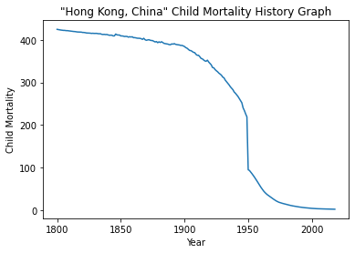

```python
y = list(child_mortality[child_mortality['country'] == 'Hong Kong, China'].iloc[0].tolist())
x = list(child_mortality.columns)
y=list(map(lambda z: float(z), y[1:]))
x=list(map(lambda z: float(z), x[1:]))
plt.plot(x,y)
plt.title('"Hong Kong, China" Child Mortality History Graph')
plt.xlabel('Year')
plt.ylabel('Child Mortality')
plt.show()
```

Let's see it's child mortality compared to population

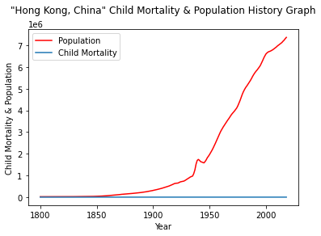

```python
y2 = list(population[population['country'] == 'Hong Kong, China'].iloc[0].tolist())
y2=list(map(lambda z: float(z), y2[1:]))
plt.plot(x,y2,'r-',label='Population')
plt.plot(x,y,label='Child Mortality')
plt.title('"Hong Kong, China" Child Mortality & Population History Graph',pad=20)
plt.xlabel('Year')
plt.ylabel('Child Mortality & Population')
plt.legend()
plt.show()
```

**[5] Posing questions and stating conclusions**

*For all countries, Is there a main trend for each metric across time?*

```python
def plt_all(df,name):
    rows_no = df.shape[0]
    years = df.columns
    years = list(map(lambda z: float(z), years[1:]))
    for i in range(0,rows_no):
        y = list(df.iloc[i].tolist())
        y = list(map(lambda z: float(z), y[1:]))
        plt.plot(years,y)
    plt.title('World '+name+' History Graph',pad=20)
    plt.xlabel('Year')
    plt.ylabel(name)
    plt.show()
```

Let's see for every metric the combination of all countries' performance

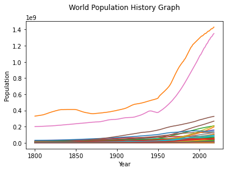

```python
plt_all(population,'Population')
```

**Population increases with time, exponentially for the most populous 2 countries and approximately quadratic for the rest of countries.**

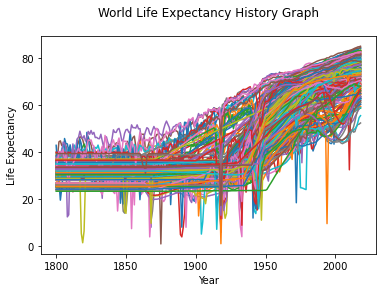

```python
plt_all(life_expec,'Life Expectancy')
```

Let's see the change in the frequency (mean value per year) between time zones "1800 to 1900", "1901 to 1950" and "1951 to 2018".

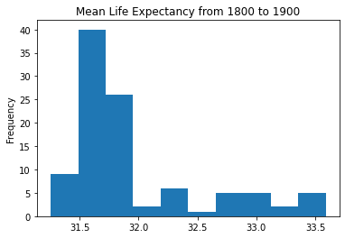

```python
life_expec.loc[:,'1800':'1900'].mean().plot(kind='hist',title='Mean Life Expectancy from 1800 to 1900');
```

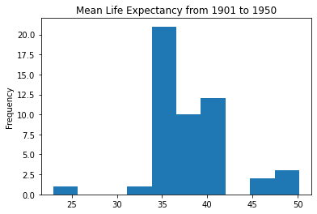

```python
life_expec.loc[:,'1901':'1950'].mean().plot(kind='hist',title='Mean Life Expectancy from 1901 to 1950');
```

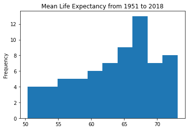

```python
life_expec.loc[:,'1951':].mean().plot(kind='hist',title='Mean Life Expectancy from 1951 to 2018');
```

**It's noticable that the mean with the highest frequency shifts from around 31.75 years to 35 years, and to 66 years, but the frequency decreases over time.**

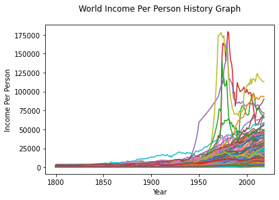

```python
plt_all(income_per_person,'Income Per Person')
```

**Income increases with time, but there was a time zone (1960 to 1990) of excessive increase for some countries followed by** **decreasing to a "rebound value", then it steadily increases again following the general trend.**

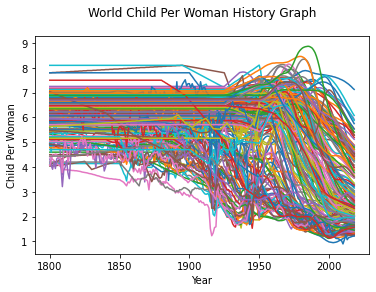

```python
plt_all(child_per_woman,'Child Per Woman')
```

**Since 1900 the trend of decreasing the number of children per woman starts.**

**Between 1800 and 1900 values are condensed between 4 to 8 children.**

Let's see the change in the frequency (mean value per year) between time zones "1800 to 1900", "1901 to 1950" and "1951 to 2018".

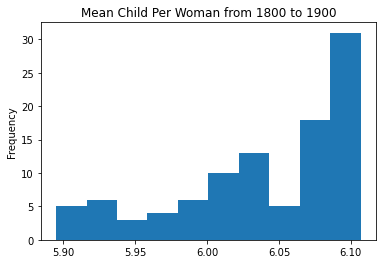

```python
child_per_woman.loc[:,'1800':'1900'].mean().plot(kind='hist',title='Mean Child Per Woman from 1800 to 1900');
```

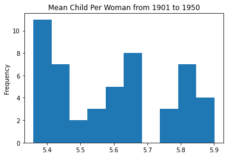

```python
child_per_woman.loc[:,'1901':'1950'].mean().plot(kind='hist',title='Mean Child Per Woman from 1901 to 1950');
```

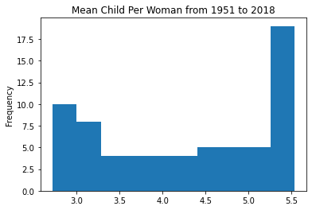

```python
child_per_woman.loc[:,'1951':].mean().plot(kind='hist',title='Mean Child Per Woman from 1951 to 2018');
```

**Families want the most possible number of children, but the globe is trying hard to decrease this trend.**

**look at the value of the highest frequency, it started from around 6 childern with 30 times of frequency, then it centered around 5 (and a half :) ) children with 18 times of frequency.**

**also notice the decrease of the lowest mean value per each time zone, it decreases over time.**

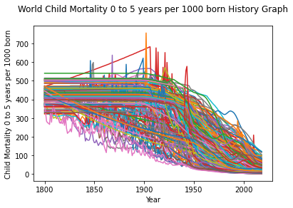

```python
plt_all(child_mortality,'Child Mortality 0 to 5 years per 1000 born')
```

**Child mortality mainly started to decrease since 1900, some countries started earlier, but mainly the majority are around 1900.**

**Globally, child mortality is decreasing with time.**

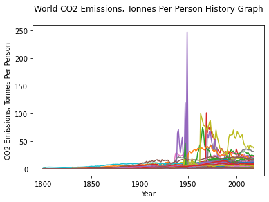

```python
plt_all(co2_per_person,'CO2 Emissions, Tonnes Per Person')
```

**Leaving the value of around (250,1950) aside .. the main trend is increasing CO2 emissions, with the occurance of rebound effect, one time around 1960 and the second time is around 2015.**

*Effect of Income per person on every other metric*

```python
def plt_against(df_x,df_y,name_x,name_y):
    rows_no = df_x.shape[0]
    for i in range(0,rows_no):
        x = list(df_x.iloc[i].tolist())
        x = list(map(lambda z: float(z), x[1:]))
        y = list(df_y.iloc[i].tolist())
        y = list(map(lambda z: float(z), y[1:]))
        plt.scatter(x,y)
    plt.title(name_y+' AGAINST '+name_x,pad=20)
    plt.xlabel(name_x)
    plt.ylabel(name_y)
    plt.show()
```

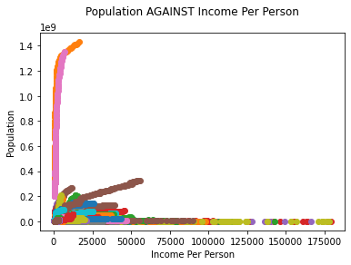

```python
plt_against(income_per_person,population,'Income Per Person','Population')
```

**However, Countries of population over 4E8 have the lowest income values ever, and all countries with income values over 50000 have small population.**

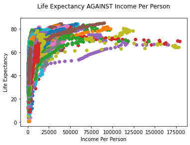

```python
plt_against(income_per_person,life_expec,'Income Per Person','Life Expectancy')
```

**This beautiful plot states that from age 45 life expectancy can be more dependant on income, but this dependency is not that strong as people would think!**

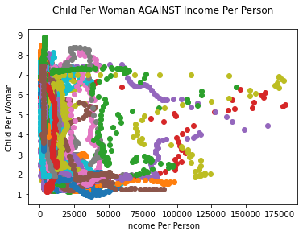

```python
plt_against(income_per_person,child_per_woman,'Income Per Person','Child Per Woman')
```

**Obviously there's no correlation between income and number of children per woman, but you can notice that women with income above 125000 have at least 4 children and at most 7 children, contrary to common lay man's sense, which is slightly applied between 100000 and 125000.**

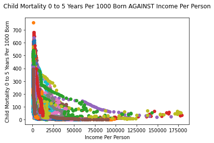

```python
plt_against(income_per_person,child_mortality,'Income Per Person','Child Mortality 0 to 5 Years Per 1000 Born')
```

**Another beautiful plot .. look at how many values near 0 mortality and how many values near 0 income .. here comes the beauty!**

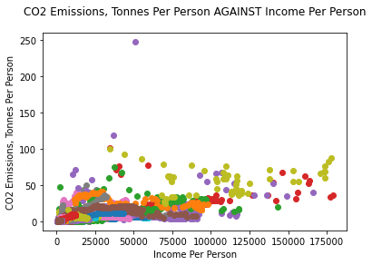

```python
plt_against(income_per_person,co2_per_person,'Income Per Person','CO2 Emissions, Tonnes Per Person')
```

**Mainly, The values are condensed within the zone "0 to 100000" income and "0 to 50" tonnes of CO2**

**Hence, income is not a major contribute to CO2 Emissions.**

# Limitations of the analysis

**(1)** From the begining, not all tables contain the same number of countries, and years of data differ as well. The maximum number of countries is 202, however the analysis is limited only to 186 country.

Population, Life Expectancy and Child Mortality tables contain data up to 2100, but this analysis is limited only to 2018, meaning that a span of 82 years for all of them **does not** contribute to this analysis.

The need for **Comparability** among all tables is the main reason for this limitation.

**(2)** Also, regarding NaN values in the table of CO2 emission, they constitute about 55.72% of the dataset ..So, setting these values to zero is merely a speculation and was applied just for the simplification of represented data. However, wars were waged, and people usually burn the remnants of their crops, and some cultures even burn their dead. In short, equalizing all values to zero among **ALL** countries before industrialization does not by any mean reflect the "unknown & not documented" actual values.

# Conclusions

### Globally

To summarize .. health condition, income and population are all running in a growth phase **Globally** .. mainly since 1900.

From a systemic point of view .. advances in technology and science in the 20th century provided the ground for these growth trends.

Life expectancy is a reflection for the overall health conditions .. but we should be somehow skeptic to take it as a solid indicator .. as people's lives can be extended with life aiding medical machines but these machines mostly don't improve the health condition.

By looking to how many children per woman, the trend is decreasing .. using lay man's logic this sounds somehow contradictory with the continuous population growth.

This means that the **CAPACITY OF GROWTH** limits the individuals' ability to reproduce.

With more people who are able to reproduce, the individual's share is decreasing .. this means the capacity of growth is not growing enough to satisfy even a **constant reproduction share** over generations.

*Constant reproduction share* over generations is modeled mathematically with perfect exponential growth function.

So, any given country with population growth that's approx. quadratic (less growth rate than exponential) must suffer from a degredation of the reproduction ability per individual over time.

Child mortality has remarkably enhanced, and the 2018's condition is the best ever globally for almost all countries.

Though, across history, this decrease is combined with small number of increasing spikes in mortality between 1900 and 2000.

Income Per Person also follows the growth trend .. some countries enjoy remarkably higher increase rate than others .. and some countries have small growth rates .. But in short, most countries have constant approx. linear growth.

Some countries enjoyed increasing spikes in income at the time between 1960 and 1990, but they were all hit with a rebound correction, then the approx. linear trend started to work again.

CO2 emissions is increasing, with the occurance of rebound effect, one time around 1960 and the second time is around 2015.

### Regarding Income Per Person

The realtions between income with life expectancy and child mortality show the positive effect income can make into increasing both of them .. however this is not a mutual dependant relation.

The minimum possible life expectancy value increases with the increase of income, and this is the beauty of the positive effect between income and life expectancy.

From age 45 life expectancy can be more dependant on income, but this dependency is not that strong.

Countries of population over 400 millions have the lowest income values ever, and all countries with income values over 50000 have small population.

There's no correlation between income and number of children per woman.

Income has positive effect on child mortality, the beauty of this positive effect comes from the decreasing of the window of max possible mortality value.

The max possible child mortality value decreases with the increase of income.

Income is not a major contribute to CO2 Emissions.